# BIOL606_hw_Lecture05_Hastings

2025-02-10

## Homework Lecture 05

**Question**: Is total male flowers affected by number of leaves AND pollination treatment (in a single linear model)?  
**Hypothesis**: Based on the results of previous t-tests on flower number vs pollination and the lack of information I have on the relationship between number of leaves and total male flowers, I believe that total male flowers are not affected by the number of leaves and pollination treatment.

```r
# Load datasets.
flowercounts <- read.csv('lecture4_flowercounts.csv') # Load in lecture4_flowercounts.csv data set.
glimpse(flowercounts)
```

```
## Rows: 8,000
## Columns: 4
## $ date  <chr> "7/9/12", "7/9/12", "7/9/12", "7/9/12", "7/9/12", "7/9/12", "7/9…
## $ plant <int> 41, 42, 43, 44, 45, 46, 47, 48, 49, 50, 51, 52, 53, 54, 55, 56, …
## $ F     <int> 0, 0, 0, 0, 0, 0, 0, 0, 0, 0, 0, 0, 0, 0, 0, 0, 0, 0, 0, 0, 0, 0…
## $ M     <int> 1, 0, 0, 0, 0, 0, 0, 0, 0, 0, 0, 0, 0, 0, 0, 0, 0, 0, 0, 0, 0, 0…
```

```r
cucumberdamage <- read.csv('lecture4_cucumberdamage.csv') # Load in lecture4_cucumberdamage.csv data set.
glimpse(cucumberdamage)
```

```
## Rows: 200
## Columns: 11
## $ plant        <int> 41, 42, 43, 44, 45, 46, 47, 48, 49, 50, 51, 52, 53, 54, 5…
## $ block        <int> 6, 6, 6, 6, 6, 6, 6, 6, 7, 7, 7, 7, 7, 7, 7, 7, 8, 8, 8, …
## $ herbivory    <chr> "H", "M", "L", "L", "O", "H", "M", "O", "L", "H", "M", "M…
## $ pollination  <chr> "NP", "HP", "HP", "NP", "HP", "HP", "NP", "NP", "NP", "HP…
## $ num_leaves   <int> 5, 9, 11, 3, 14, 2, 3, 10, 5, 1, 13, 13, 12, 8, 10, 4, 9,…
## $ leaf1length  <dbl> 7.5, 9.0, 7.5, 5.0, 9.5, 5.0, 7.0, 8.6, 6.6, 5.5, 6.7, 8.…
## $ leaf1percdam <int> 0, 0, 0, 0, 5, 15, 0, 10, 0, 10, 0, 0, 1, 0, 1, 1, 2, 0, …
## $ leaf2length  <dbl> 10.0, 10.0, 8.0, 5.5, 10.5, 7.5, 10.5, 10.0, 5.8, NA, 7.7…
## $ leaf2percdam <int> 1, 0, 10, 5, 10, 10, 10, 0, 0, NA, 0, 1, 0, 3, 1, 0, 1, 5…
## $ leaf3length  <dbl> 11.0, 9.0, 9.5, 7.7, 10.0, NA, 6.0, 11.0, 7.6, NA, 8.9, 6…
## $ leaf3percdam <int> 5, 5, 2, 0, 2, NA, 0, 5, 0, NA, 0, 5, 1, 5, 3, 50, 5, 0, …
```

```r
cucumberdamage$plant <- as.factor(cucumberdamage$plant) # Encode flowercounts$plant variable into a categorical variable since it represents individual plant IDs.

flowercounts$plant <- as.factor(flowercounts$plant) # Encode flowercounts$plant variable into a categorical variable since it represents individual plant IDs.

male_counts <- flowercounts %>%
  filter(!is.na(plant)) %>% # Remove rows with plant variable is NA.
  group_by(plant) %>% # Group the data by the 'plant' column.
  summarise(total_male_flowers = sum(M, na.rm = TRUE)) # For each plant, sum up 'M', ignoring NAs.

male_counts %>% slice_sample(n = 10) # Check a random 10 rows to check new variable.
```

```
## # A tibble: 10 × 2
##    plant total_male_flowers
##    <fct>              <int>
##  1 54                   272
##  2 230                  239
##  3 107                  131
##  4 133                  325
##  5 144                  309
##  6 43                   241
##  7 203                  152
##  8 194                  143
##  9 120                  281
## 10 152                  524
```

```r
cucumberdamage$pollination <- as.factor(cucumberdamage$pollination) # Encode cucumberdamage$pollination variable into a categorical variable.

cucumberdamage <- left_join(cucumberdamage, (male_counts %>% select(plant, total_male_flowers)), by = 'plant') # Join total_male$total_male_flowers to cucumberdamage using plant variable as the common key column.

cucumberdamage %>% slice_sample(n = 10) # Check a random 10 rows to check new variable.
```

```
##    plant block herbivory pollination num_leaves leaf1length leaf1percdam
## 1    188    24         L          NP          9         9.5            0
## 2    130    17         H          HP         13         8.0            3
## 3    138    18         M          HP         13         9.5            0
## 4     84    11         O          NP         16         7.0            1
## 5    218    28         H          NP         10         8.7            1
## 6    152    19         O          NP         14         9.7            1
## 7    220    28         L          HP          9         9.0            0
## 8    210    27         L          HP          8         9.5            0
## 9    180    23         L          HP         10         8.5            0
## 10   187    24         O          NP         10         9.7            0
##    leaf2length leaf2percdam leaf3length leaf3percdam total_male_flowers
## 1         10.4            0        12.5            3                131
## 2         10.5            0         9.8            0                214
## 3         10.0            0         8.5            5                258
## 4          7.5            1         9.5            0                494
## 5          9.5            2        11.5            3                193
## 6          9.8            3          NA           40                524
## 7         11.4            0        12.9            4                351
## 8         10.8            0        12.1            2                132
## 9          9.8            0        11.5            2                193
## 10        10.6            0        12.8            0                175
```

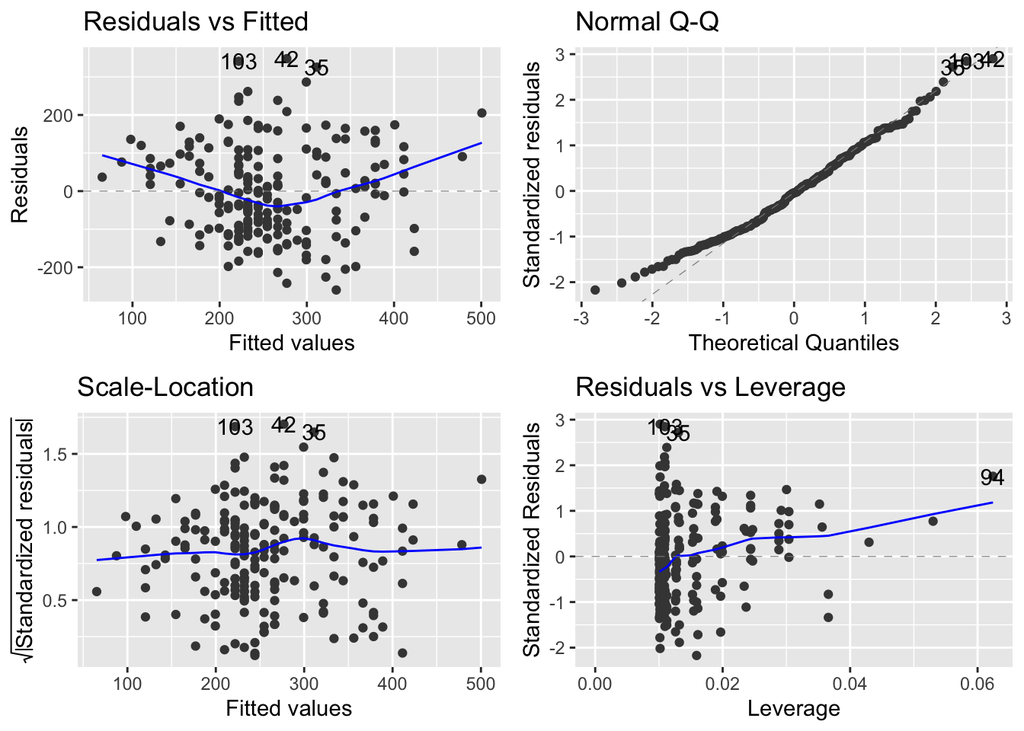

```r
# Create general linear model.
model <- lm(total_male_flowers ~ num_leaves + pollination, data = cucumberdamage)

autoplot(model)
```

```r
anova(model)
```

```
## Analysis of Variance Table
##
## Response: total_male_flowers
##              Df  Sum Sq Mean Sq F value    Pr(>F)
## num_leaves    1 1077766 1077766  74.168 2.296e-15 ***
## pollination   1    5420    5420   0.373    0.5421
## Residuals   197 2862689   14531
## ---
## Signif. codes:  0 '***' 0.001 '**' 0.01 '*' 0.05 '.' 0.1 ' ' 1
```

```r
summary(model)
```

```
##
## Call:
## lm(formula = total_male_flowers ~ num_leaves + pollination, data = cucumberdamage)
##
## Residuals:
##     Min      1Q  Median      3Q     Max
## -259.73  -94.58   -5.05   85.44  347.98
##
## Coefficients:
##               Estimate Std. Error t value Pr(>|t|)
## (Intercept)     42.885     27.290   1.571    0.118
## num_leaves      22.373      2.596   8.617 2.22e-15 ***
## pollinationNP   10.412     17.049   0.611    0.542
## ---
## Signif. codes:  0 '***' 0.001 '**' 0.01 '*' 0.05 '.' 0.1 ' ' 1
##
## Residual standard error: 120.5 on 197 degrees of freedom
## Multiple R-squared:  0.2745, Adjusted R-squared:  0.2671
## F-statistic: 37.27 on 2 and 197 DF,  p-value: 1.871e-14
```

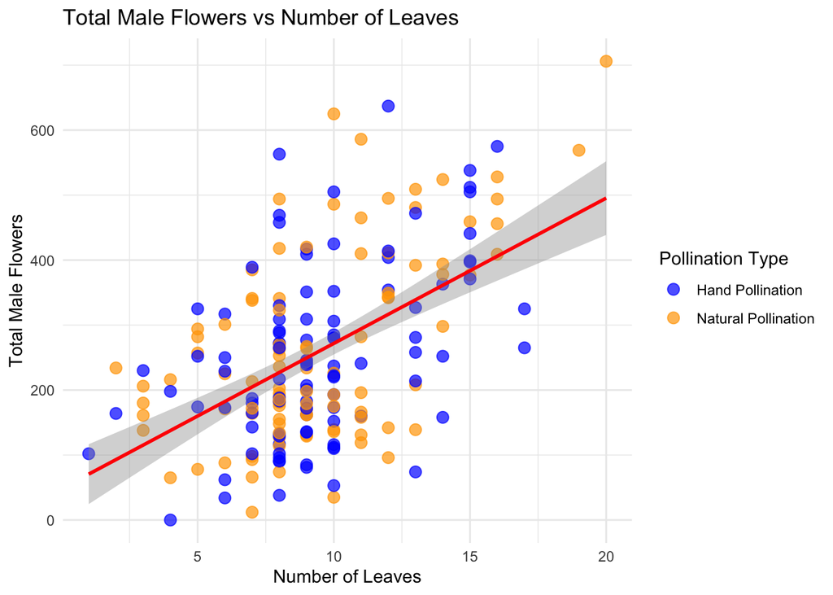

```r
# Plot results.
results = ggplot(cucumberdamage, aes(x = num_leaves, y = total_male_flowers, color = pollination)) +
  geom_point(size = 3, alpha = 0.7) + # Scatter plot with transparency, colored by pollination type.
  geom_smooth(method = 'lm', se = TRUE, color = 'red') + # Regression line.
  scale_color_manual(
    name = 'Pollination Type', # Pollination type legend.
    values = c('HP' = 'blue', 'NP' = 'orange'),
    labels = c('HP' = 'Hand Pollination', 'NP' = 'Natural Pollination')) +
  labs(title = 'Total Male Flowers vs Number of Leaves',
       x = 'Number of Leaves',
       y = 'Total Male Flowers',
       color = 'Pollination Type') +
  theme_minimal()

results
```

Looking at the autoplot of the model:  
- The Residual vs Fitted plot does not demonstrate random scatter implying non-linearity in the data.  
- The Normal Q-Q plot demonstrates a normality of residuals.  
- The Scale-Location plot demonstrates consistent variance.  
- The Residuals vs Leverage plot demonstrates that most points have low leverage.  
Looking at the ANOVA analysis of the model:  
- Number of leaves has a strong effect on the number of male flowers. (p = 2.296e-15)  
- Pollination type does not have a strong effect on the number of male flowers. (p = 0.5421)  
- The Sum Sq value indicates unexplained variation remains.  
Looking at the summart of the model:  
- The extreme residuals mean there might be a lot of deviation/outliers.  
- Number of leaves is highly predictive of number of male flowers, for each additional leaf, the number of male flowers increases by ~22.37.  
- High RSE suggests the model has a good amount of unexplained variability. The low R^2 value also suggests this (other explanatory factors may be missing).  
- The F-stat = 37.27, p = 1.871e-14 means the model explains a good amount of variance.  
**Conclusion:** The total number of male flowers is affected by the number of leaves but not by the pollination treatment.

# Beckerman Chapter 7

- GLMs are used for non-normal data, such as count or proportion data. Count data is discrete and bounded at zero.
- These models extend linear regression by allowing the response variable to follow distributions other than normal (e.g., Poisson, binomial).
- Family: Specifies the probability distribution of the response variable.
- Linear predictor: Describes how explanatory variables influence the response variable.
- Link function: Connects the linear predictor to the expected value of the response variable.
- The Poisson distribution is commonly used for count data.
- The variance in Poisson-distributed data increases with the mean.
- Traditional linear regression is not suitable for count data due to the possibility of negative predictions.  
  Diagnostics:
- Akaike Information Criterion (AIC) is used for model selection (lower AIC = better model fit).
- Over-dispersion occurs when the variance is larger than expected under a Poisson model.

```r
# Load libraries.
library(ggplot2)
library(dplyr)
library(MASS)
soay <- read.csv('SoaySheepFitness.csv') # Load in SoaySheepFitness.csv data set.

glimpse(soay)
```

```
## Rows: 50
## Columns: 2
## $ fitness   <int> 4, 3, 2, 14, 5, 2, 2, 5, 8, 4, 12, 6, 3, 2, 3, 0, 5, 3, 5, 6…
## $ body.size <dbl> 6.373546, 7.183643, 6.164371, 8.595281, 7.329508, 6.179532, …
```

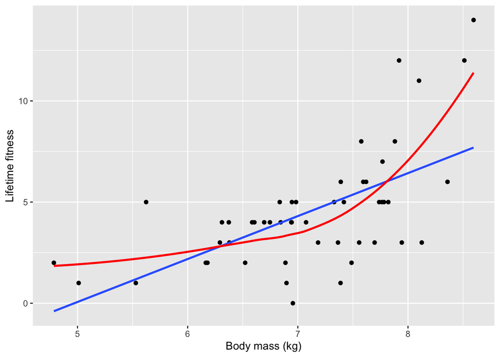

```r
# Create a scatter plot with fitted lines.
ggplot(soay, aes(x = body.size, y = fitness)) +
  geom_point() +
  geom_smooth(method = 'lm', se = FALSE) +
  geom_smooth(span = 1, colour = 'red', se = FALSE) +
  xlab('Body mass (kg)') + ylab('Lifetime fitness')
```

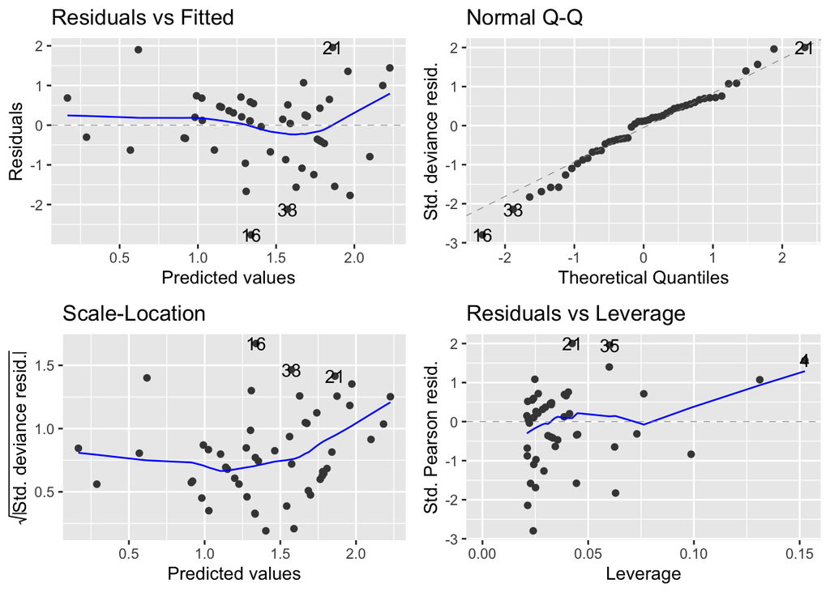

```r
# Poisson GLM.
soay.glm <- glm(fitness ~ body.size, data = soay, family = poisson)

# Alternative explicit link function specification.
soay.glm <- glm(fitness ~ body.size, data = soay, family = poisson(link = 'log'))

autoplot(soay.glm)
```

```r
anova(soay.glm, test = 'Chisq')
```

```
## Analysis of Deviance Table
##
## Model: poisson, link: log
##
## Response: fitness
##
## Terms added sequentially (first to last)
##
##
##           Df Deviance Resid. Df Resid. Dev  Pr(>Chi)
## NULL                         49     85.081
## body.size  1   37.041        48     48.040 1.157e-09 ***
## ---
## Signif. codes:  0 '***' 0.001 '**' 0.01 '*' 0.05 '.' 0.1 ' ' 1
```

```r
summary(soay.glm)
```

```
##
## Call:
## glm(formula = fitness ~ body.size, family = poisson(link = "log"),
##     data = soay)
##
## Coefficients:
##             Estimate Std. Error z value Pr(>|z|)
## (Intercept) -2.42203    0.69432  -3.488 0.000486 ***
## body.size    0.54087    0.09316   5.806 6.41e-09 ***
## ---
## Signif. codes:  0 '***' 0.001 '**' 0.01 '*' 0.05 '.' 0.1 ' ' 1
##
## (Dispersion parameter for poisson family taken to be 1)
##
##     Null deviance: 85.081  on 49  degrees of freedom
## Residual deviance: 48.040  on 48  degrees of freedom
## AIC: 210.85
##
## Number of Fisher Scoring iterations: 4
```

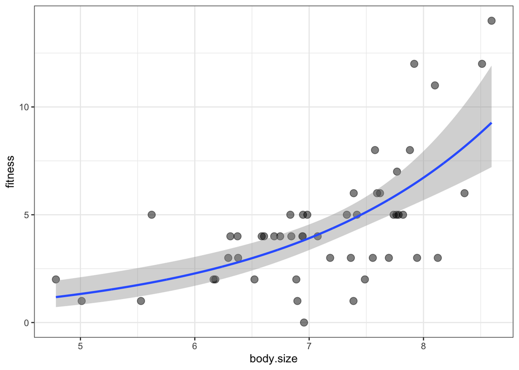

```r
# Generate new data for prediction.
min.size <- min(soay$body.size)
max.size <- max(soay$body.size)
new.x <- expand.grid(body.size = seq(min.size, max.size, length = 1000))

# Predict values with standard errors.
new.y <- predict(soay.glm, newdata = new.x, se.fit = TRUE)
new.y <- data.frame(new.y)

# Combine predictions.
addThese <- data.frame(new.x, new.y)

# Back-transform predictions from log scale to response scale.
addThese <- mutate(addThese,
                   fitness = exp(fit),
                   lwr = exp(fit - 1.96 * se.fit),
                   upr = exp(fit + 1.96 * se.fit))

# Final plot with fitted GLM and confidence intervals.
ggplot(soay, aes(x = body.size, y = fitness)) +
  geom_point(size = 3, alpha = 0.5) +
  geom_smooth(data = addThese, aes(ymin = lwr, ymax = upr), stat = 'identity') +
  theme_bw()
```

```r
# Checking for over-dispersion.
dispersion_index <- summary(soay.glm)$deviance / summary(soay.glm)$df.residual
print(dispersion_index) # Should be close to 1.
```

```
## [1] 1.000843
```

```r
# Quasi-Poisson model.
soay.quasi <- glm(fitness ~ body.size, data = soay, family = quasipoisson)

anova(soay.quasi, test = 'F')
```

```
## Analysis of Deviance Table
##
## Model: quasipoisson, link: log
##
## Response: fitness
##
## Terms added sequentially (first to last)
##
##
##           Df Deviance Resid. Df Resid. Dev      F Pr(>F)
## NULL                         49     85.081
## body.size  1   37.041        48     48.040 41.033  6e-08 ***
## ---
## Signif. codes:  0 '***' 0.001 '**' 0.01 '*' 0.05 '.' 0.1 ' ' 1
```

```r
# Negative binomial model.
soay.nb <- glm.nb(fitness ~ body.size, data = soay)
summary(soay.nb)
```

```
##
## Call:
## glm.nb(formula = fitness ~ body.size, data = soay, init.theta = 31275.1986,
##     link = log)
##
## Coefficients:
##             Estimate Std. Error z value Pr(>|z|)
## (Intercept) -2.42192    0.69437  -3.488 0.000487 ***
## body.size    0.54086    0.09317   5.805 6.43e-09 ***
## ---
## Signif. codes:  0 '***' 0.001 '**' 0.01 '*' 0.05 '.' 0.1 ' ' 1
##
## (Dispersion parameter for Negative Binomial(31275.2) family taken to be 1)
##
##     Null deviance: 85.068  on 49  degrees of freedom
## Residual deviance: 48.033  on 48  degrees of freedom
## AIC: 212.85
##
## Number of Fisher Scoring iterations: 1
##
##
##               Theta:  31275
##           Std. Err.:  1187025
## Warning while fitting theta: iteration limit reached
##
##  2 x log-likelihood:  -206.848
```